[figure not shown]

S2 Statistika Terapan FMIPA Universitas Padjadjaran

Research Skills · Coaching Riset

# Coaching Riset S2 Statistika Terapan

Mematangkan metodologi, mempertajam kontribusi ilmiah, dan memastikan kesiapan mahasiswa menuju Seminar Usulan Riset.

📅 **Sabtu, 15 Agustus 2026**

🕗 08:00 WIB–selesai

📍 Gedung Statistika FMIPA Unpad

👥 2 mahasiswa · 1 coach

Berita Kegiatan

Program Studi S2 Statistika Terapan FMIPA Universitas Padjadjaran menyelenggarakan Coaching Riset secara luring pada Sabtu, 15 Agustus 2026, mulai pukul 08:00 WIB hingga selesai di Gedung Statistika FMIPA Unpad. Kegiatan ini dirancang sebagai ruang akademik intensif untuk mematangkan rancangan penelitian mahasiswa menjelang Seminar Usulan Riset (SUR).

Coaching diikuti oleh dua mahasiswa, Angga Pratama dan Sri Yuli, dengan pendampingan langsung Kaprodi S2 Statistika Terapan, I Gede Nyoman Mindra Jaya. Diskusi berlangsung dalam format dialogis: setiap mahasiswa memaparkan perkembangan riset, kemudian bersama coach menelaah kembali rumusan masalah, struktur metodologi, kebutuhan data, strategi evaluasi, hingga logika interpretasi hasil.

## Dua Topik, Satu Tujuan: Riset yang Siap Diuji

Angga Pratama

### Hybrid Ordinal Logit Model

Pembahasan difokuskan pada pemodelan respons ordinal, posisi komponen hibrida dalam model, asumsi yang perlu diuji, alasan pemilihan pendekatan, serta bagaimana hasil model dapat diinterpretasikan secara substantif.

Sri Yuli

### Analisis Image

Diskusi menyoroti alur analisis citra, representasi input, ekstraksi fitur, encoder–decoder, dan arsitektur vision transformer untuk memastikan fondasi metodologis penelitian dapat dijelaskan dengan kuat.

## Diskusi yang Produktif dan Terarah

Sesi coaching tidak berhenti pada pertanyaan “metode apa yang digunakan?”, tetapi bergerak ke pertanyaan yang lebih penting: masalah ilmiah apa yang ingin dijawab, mengapa metode tersebut tepat, bukti empiris apa yang diperlukan, dan bagaimana kontribusi penelitian dapat dipertanggungjawabkan. Pola diskusi ini membantu mahasiswa melihat proposal sebagai satu kesatuan antara masalah, metode, data, evaluasi, dan interpretasi.

**Hasil utama coaching:** kedua mahasiswa menunjukkan kemajuan yang baik dan dinilai semakin siap untuk memasuki tahap pemantapan akhir menuju SUR pada minggu berikutnya. Fokus akhir diarahkan pada konsistensi proposal, ketajaman novelty atau kontribusi, dan kesiapan menjawab argumentasi metodologis.

## Capaian Pertemuan

- Rumusan masalah dan pertanyaan riset menjadi lebih terarah.
- Pemilihan metodologi dikaitkan langsung dengan tujuan penelitian.
- Alur data–model–evaluasi–interpretasi diperiksa agar konsisten.
- Bagian yang perlu dipertajam sebelum SUR telah diidentifikasi.
- Mahasiswa memperoleh agenda tindak lanjut yang konkret.

[figure not shown]

Program Penguatan Kompetensi Riset

### Research Skills Bootcamp

Coaching riset merupakan bagian dari penguatan ekosistem akademik program studi agar mahasiswa tidak hanya mampu menjalankan metode, tetapi juga mampu menjelaskan logika ilmiah, menjaga reproducibility, dan membangun riset yang mempunyai kontribusi nyata.

Dokumentasi

## Suasana Coaching Riset

Gedung Statistika FMIPA Unpad · 15 Agustus 2026

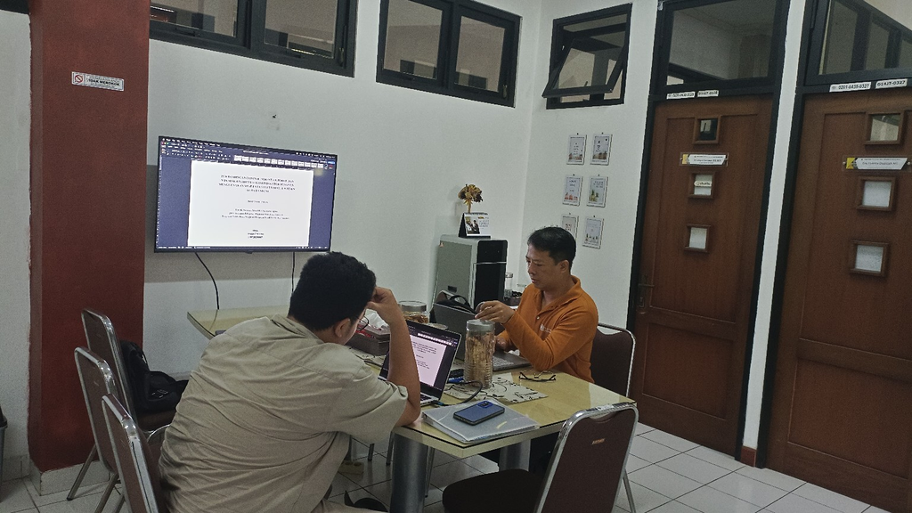

[figure not shown]

[figure not shown]

[figure not shown]

[figure not shown]

[figure not shown]

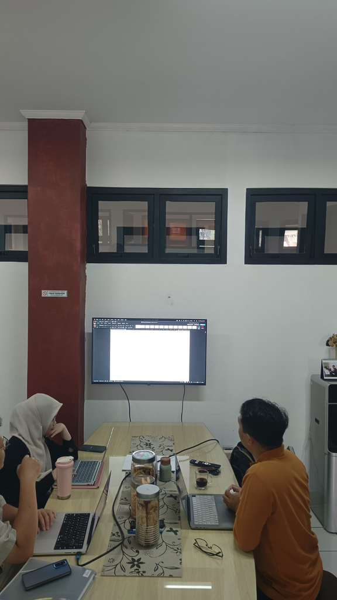

**22**Agustus 2026

Agenda Berikutnya

## Coaching Dilanjutkan Minggu Depan

Pendampingan berikutnya akan dilaksanakan pada Sabtu, 22 Agustus 2026 secara luring di Gedung Statistika FMIPA Unpad. Pertemuan akan digunakan untuk menindaklanjuti hasil coaching dan memperkuat kesiapan akademik mahasiswa pada tahapan riset selanjutnya.